# Storm Database analysis: most devastating events in the United States, years 1952 - 2011

## 3. Results

First, let’s answer this question:

> 1. Across the United States, which types of events (as indicated in the `EVTYPE` variable) are most harmful with respect to population health?

Looking at top 5 most damaging events related to health:

```r
storm_health %>%
    group_by(event_type) %>%
    summarise(total_damage = sum(damage)) %>%
    arrange(desc(total_damage)) %>%
    head(5)
```

| event_type | total_damage |
| --- | --- |
| TORNADO | 96979 |
| EXCESSIVE HEAT | 8428 |
| TSTM WIND | 7461 |
| FLOOD | 7259 |
| LIGHTNING | 6046 |

Let’s build plot to compare top 5 most harmful events related to fatalities and injuries:

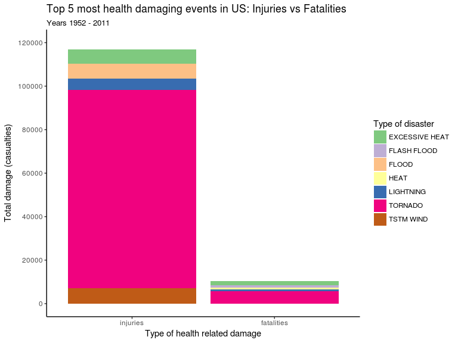

```r
library(ggplot2)
library(ggthemes)
# Create a tibble with 5 most harful event related to fatalities
top5_fatalities <- storm_health %>%
    filter(damage_type == "fatalities") %>%
    group_by(event_type, damage_type) %>%
    summarise(total_damage = sum(damage)) %>%
    arrange(desc(total_damage)) %>%
    head(5)
# Create a tibble with 5 most harful event related to injuries
top5_injuries <- storm_health %>%
    filter(damage_type == "injuries") %>%
    group_by(event_type, damage_type) %>%
    summarise(total_damage = sum(damage)) %>%
    arrange(desc(total_damage)) %>%
    head(5)
# Combine two tibbles into one
top5_health <- bind_rows(top5_injuries, top5_fatalities)
# Reorder levels of damage_type, to display injuries first
top5_health$damage_type <-  factor(top5_health$damage_type, levels = c("injuries", "fatalities"))
# Plot stack bar plot
top5_health %>%
    ggplot(aes(x = damage_type, y = total_damage, fill=event_type)) +
        geom_col() +
        scale_y_continuous(limits = c(0, 120000), breaks = seq(0, 120000, 20000)) +
        scale_fill_brewer(palette="Accent") +
        labs(x = "Type of health related damage",
             y = "Total damage (casualties)",
             fill = "Type of disaster") +
        ggtitle("Top 5 most health damaging events in US: Injuries vs Fatalities", subtitle = "Years 1952 - 2011") +
        ggplot2::theme_classic()
```

And the second question:

> 2. Across the United States, which types of events have the greatest economic consequences?

Top 5 most damaging events related to economics:

```r
storm_economic %>%
    group_by(event_type) %>%
    summarise(total_damage = sum(damage)) %>%
    arrange(desc(total_damage)) %>%
    head(5)
```

| event_type | total_damage |
| --- | --- |
| TORNADO | 3312277 |
| FLASH FLOOD | 1599325 |
| TSTM WIND | 1445168 |
| HAIL | 1268290 |
| FLOOD | 1067976 |

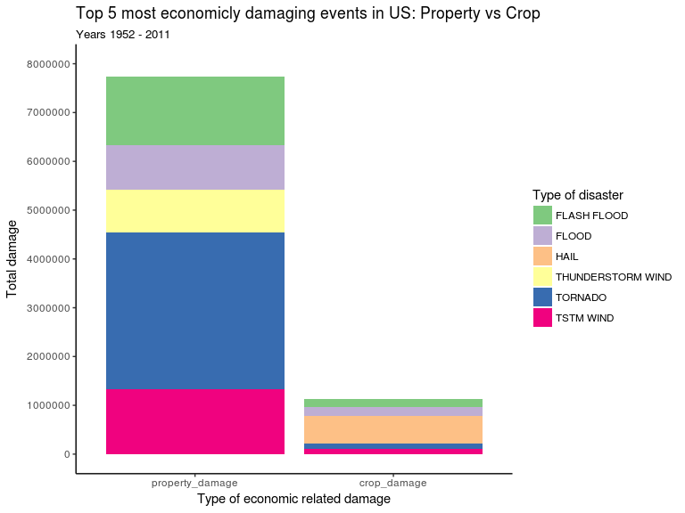

```r
library(ggplot2)
library(ggthemes)
# Create a tibble with 5 most harful event related to property damage
top5_prop_damage <- storm_economic %>%
    filter(damage_type == "property_damage") %>%
    group_by(event_type, damage_type) %>%
    summarise(total_damage = sum(damage)) %>%
    arrange(desc(total_damage)) %>%
    head(5)
# Create a tibble with 5 most harful event related to crop damage
top5_crop_damage <- storm_economic %>%
    filter(damage_type == "crop_damage") %>%
    group_by(event_type, damage_type) %>%
    summarise(total_damage = sum(damage)) %>%
    arrange(desc(total_damage)) %>%
    head(5)
# Combine two tibbles into one
top5_economics <- bind_rows(top5_prop_damage, top5_crop_damage)
# Reorder levels of damage_type, to display property damage first
top5_economics$damage_type <-  factor(top5_economics$damage_type, levels = c("property_damage", "crop_damage"))
# Turn off scientific notation
options(scipen=999)
# Plot stack bar plot
top5_economics %>%
    ggplot(aes(x = damage_type, y = total_damage, fill=event_type)) +
        geom_col() +
        scale_y_continuous(limits = c(0, 8000000), breaks = seq(0, 8000000, 1000000)) +
        scale_fill_brewer(palette="Accent") +
        labs(x = "Type of economic related damage",
             y = "Total damage",
             fill = "Type of disaster") +
        ggtitle("Top 5 most economicly damaging events in US: Property vs Crop", subtitle = "Years 1952 - 2011") +
        ggplot2::theme_classic()
```